# stm_model_estimation

# Time effects

- График конечно не очень, но видим, что большинство тем имеют более менее одинаковую динамику на всем периоды ( что-то вроде шума, хотя и нет ).

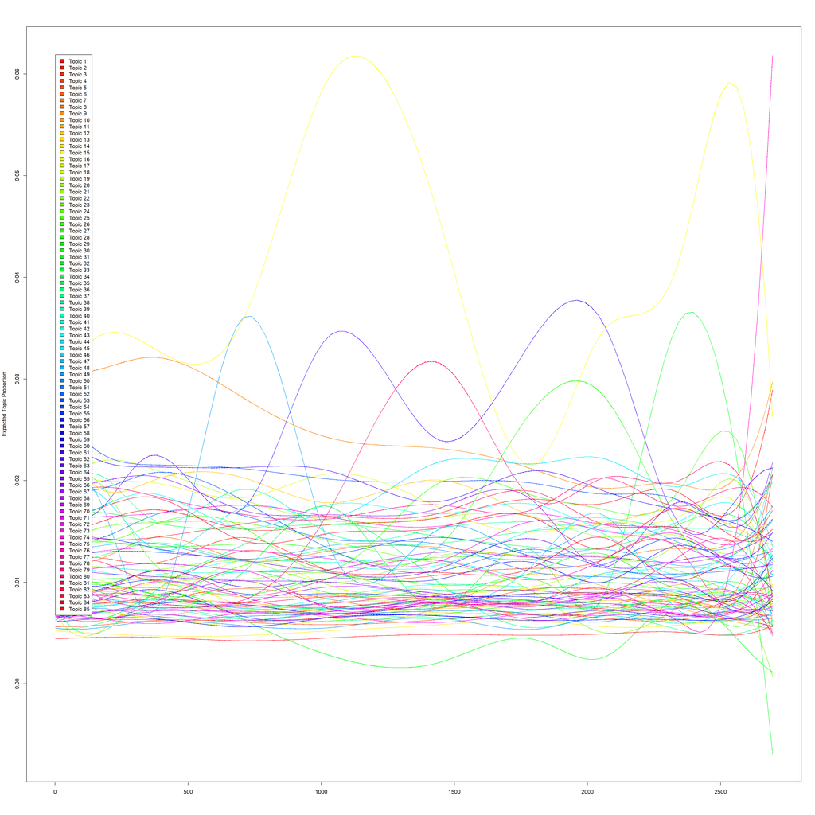

```r
time_dependency <- plot(prep, "Time", method = 'continuous',  moderator = "Type", moderator.value = "domestic",ci.level = 0 )
```

# Что можно сделать тут?

Как раз таки тут можно попробовать концептуализировать понятие зашумления ( помимо того, что просто еще смотрим на доли). Видим присутсвие тем, чьи доли не меняются ни в зависимости от модератора ни в зависимости от времени как факторы - возможно это можно трактовать как шум + смотрим динамики, что постепенно падает или очень низко находится по пропорции независимо. В общем сама идея засунуть время не как просто динамику, а именно значимый фактор ( estimate effect ) - возможно имеет смысл.

# В принципе, что получилось наверное неплохо:

1. топики достаточно специфичны и имеют смысл (иногда даже какой-то специфический смысл)
2. чуть-чуть смысла от гипотезы деления на внутреннюю/внешнюю повестку есть ( по крайней мере можно показать какие-то эффекты)